# IAU2 TP3

Guadalupe Atienza Rela

3/10/2021

## **Introducción**

En este trabajo volveremos sobre los datos que exploramos en el TP1, en relación al acceso informal al hábitat urbano en la Ciudad de Buenos Aires. En esta opotunidad, trabajaremos con visualizaciones, para lo cual será necesario realizar alguans transformaciones adicionales sobre los mismos.

Comenzamos activando los paquetes que utilizaremos para importar, ordenar, transformar y visualizar estos datos e importando los sets de datos a utilizar:

```r
library(tidyverse)
library(janitor)
library(sf)
library(ggmap)
library(patchwork)
```

Seguidamente, heemos importado los tres data sets con los que vamos a trabajar: se trata de tres mismos sets de datos espaciales del portal de datos abiertos del GCBA que hemos utilizado en el trabajo anterior. El primero de ellos contiene datos de las *villas, asentamientos, conjuntos habitacionales y núcleos habitacionales transitorios (NHT)* de la ciudad de Buenos Aires; el segundo, *datos sociodemográficos* correspondienteas al último censo para cada uno de los radios censales de la ciudad; y, finalmente, el tercero, las geometrías de los polígonos de sus *comunas*.

```r
barriosp <- st_read("data/barrios_vulnerables_caba/barrios_vulnerables.shp")
barriosp <- st_transform(barriosp, crs=4326)
datos_censales_xradio <- st_read("data/caba_radios_censales.geojson")
comunas_caba <- st_read("data/comunas_caba.geojson")
```

## **Visualizaciones**

Como es sabido, existen diversas formas de acceso informal y precario al habitat urano. Se trata de distintas situaciones de tenencia *informal* que ponen en juego diferentes estrategias individuales o colectivas que intentan resolver, aunque siempre de manera *precaria*, el **problema del acceso al hábitat en la ciudad**. Las primeras se insertan en la trama urbana existente (ocupaciones de inmuebles abandonados, alquiler de piezas en inquilinatos, etc), mientras las segundas, en las cuales nos enfocaremos en este trabajo, corresponden al desarrollo de nuevas urbanizaciones. Estas pueden haber surgido inicialmente como formas de urbanización informal, como es el caso de las *villas* y *asentamientos*, o no, como es el caso de los barrios que tienen su origen en *conjuntos habitacionales* construidos por el Estado, ya sea que éstos hubieran sido pensados como alojamientos *transitorios* que luego se consolidaron o que, siendo de carácter *definitivo*, tuvieron procesos de escrituración inconclusos y sufrieron nuevas ocupaciones.

Comenzamos entonces, por identificar estos barrios en la ciudad:

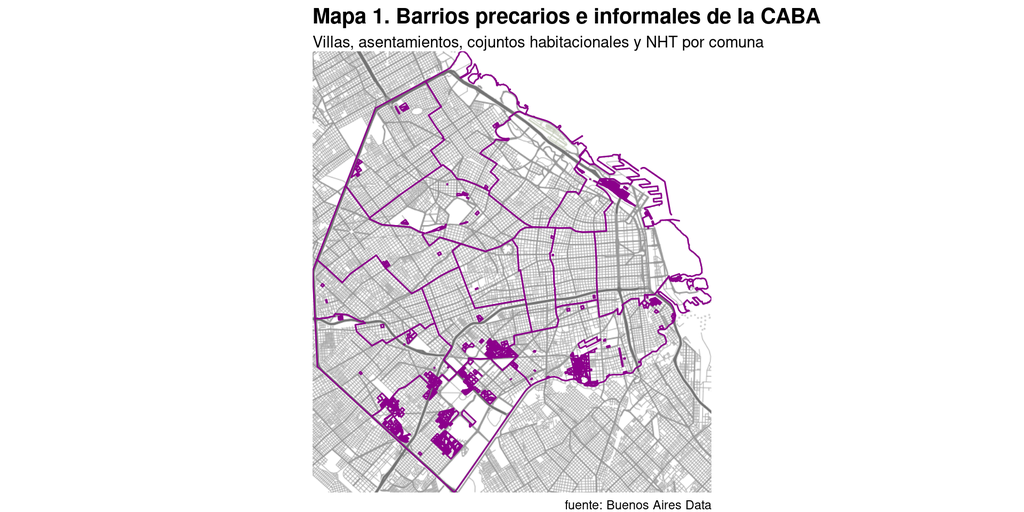

```r
bbox_comunas <- as.numeric(st_bbox(comunas_caba))
mapa_caba <- get_stamenmap(bbox = bbox_comunas, maptype = "terrain-lines", zoom=12)
ggmap(mapa_caba)+
  geom_sf(data=comunas_caba, color="darkmagenta", fill= NA, inherit.aes = FALSE)+
  geom_sf(data=barriosp, color="darkmagenta", inherit.aes = FALSE)+
  theme_void() +
    theme(plot.title = element_text(face="bold", size=15)) +
    labs(title = "Mapa 1. Barrios precarios e informales de la CABA",
    subtitle = "Villas, asentamientos, cojuntos habitacionales y NHT por comuna",
    caption = "fuente: Buenos Aires Data")
```

Para las visualizaciones que presentamos a continuación, hemos trabajado con datos demográficos del CENSO de 2010 correspondientes a los radios censales comprendidos dentro de los polígonos donde se emplazan estos barrios:

```r
poligono_barriosp <- st_union(barriosp)
```

```
## although coordinates are longitude/latitude, st_union assumes that they are planar
```

```r
datos_censales_bp <- datos_censales_xradio %>%
                     st_intersection(poligono_barriosp) %>%
                     st_set_geometry(NULL) %>%
                     clean_names() %>%
                     mutate(comuna=paste("Comuna ", comuna))
```

```
## although coordinates are longitude/latitude, st_intersection assumes that they are planar
```

### *i) Gráfico de Barras*

En el gráfico de barras que se presenta a continuación puede verse que la mayor proporción de *población*, *hogares* y *viviendas* de villas, asentamientos, conjuntos habitacionales y núcleos habitacionales transitorios (NHT) se concentra en las **comunas 8, 4, 7, 1 y 9**.

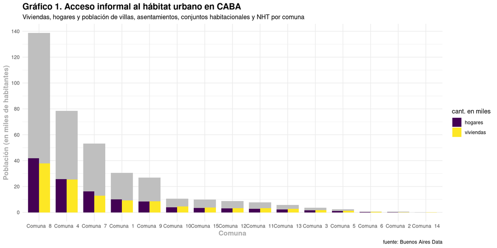

```r
ggplot()+
   geom_bar(data=datos_censales_bp %>%
              group_by(comuna) %>%
              summarise(poblacion=sum(poblacion)/1000),
              mapping=aes(y=poblacion, x=fct_reorder(comuna,desc(poblacion))),
              stat="identity", fill="grey75", width = 0.8)+
   geom_bar(data=datos_censales_bp %>%
            group_by(comuna) %>%
            summarise(hogares=sum(hogares)/1000,
                      viviendas=sum(viviendas)/1000) %>%
            pivot_longer(cols = 2:3,
                         names_to ="indicador", values_to = "cantidad"),
            mapping=aes(fill=indicador,
                        y=cantidad, x=comuna),
            stat="identity", position="dodge", width = 0.8) +
    scale_fill_viridis_d()+
    scale_y_continuous(breaks = seq(0, 140, 20))+
    theme_minimal() +
    theme(plot.title = element_text(face="bold", size=15)) +
    theme(axis.title.x = element_text(face="bold", colour="darkgray", size=12)) +
    theme(axis.title.y = element_text(face="bold", colour="darkgray", size=12)) +
    labs(title = "Gráfico 1. Acceso informal al hábitat urbano en CABA",
    subtitle = "Viviendas, hogares y población de villas, asentamientos, conjuntos habitacionales y NHT por comuna",
    x = "Comuna",
    y = "Población (en miles de habitantes)",
    caption = "fuente: Buenos Aires Data",
    fill = "cant. en miles")
```

La tabla que se presenta a continuación muestra los datos de población, hogares y viviendas para cada una de las comunas de la ciudad:

```r
tabla_resumen <- datos_censales_bp %>%
                 group_by(comuna) %>%
                 summarise(poblacion=sum(poblacion),
                           hogares=sum(hogares),
                           viviendas=sum(viviendas)) %>%
                 arrange(desc(poblacion))
tabla_resumen
```

```
## # A tibble: 15 x 4
##    comuna     poblacion hogares viviendas
##    <chr>          <dbl>   <dbl>     <dbl>
##  1 Comuna  8     138776   41914     37905
##  2 Comuna  4      78515   25703     25357
##  3 Comuna  7      53153   16253     12981
##  4 Comuna  1      30556   10141      9195
##  5 Comuna  9      26842    8388      8510
##  6 Comuna  10     10590    3866      4536
##  7 Comuna  15      9976    3404      3735
##  8 Comuna  12      8774    3027      3183
##  9 Comuna  11      7679    2847      3245
## 10 Comuna  13      5720    2220      2834
## 11 Comuna  3       3522    1517      1833
## 12 Comuna  5       2476    1018      1313
## 13 Comuna  6        629     288       373
## 14 Comuna  2        623     154       138
## 15 Comuna  14        25       6        21
```

Si bien en el presente análisis no nos estamos enfocando en una comparación de los datos sociodemográficos de estos barrios con los del resto de la ciudad, en el gráfico precedente puede apreciarse que en varias comunas la cantidad de hogares se encuentra por encima de la cantidad de viviendas, es decir, se registra hacinamiento de hogares; lo cual contrasta con la existencia de vivienda ociosa presente en la ciudad cuando se la considera de conjunto. Para cuantificar esta impresión a simple vista, a continuación calculamos el tamaño promedio del hogar y el promedio de hogares por vivienda en villas y asentamientos y para el conjunto de la ciudad.

- Promedio de hogares por vivienda en barrios precarios e informales:

```r
prom_hogares_por_vivienda <- sum(tabla_resumen$hogares)/sum(tabla_resumen$viviendas)
prom_hogares_por_vivienda
```

```
## [1] 1.048516
```

- Promedio de hogares por vivienda en CABA:

```r
prom_hogaresxvivienda_caba <- sum(datos_censales_xradio$HOGARES)/sum(datos_censales_xradio$VIVIENDAS)
prom_hogaresxvivienda_caba
```

```
## [1] 0.8062979
```

- Tamaño promedio del hogar en barrios precarios e informales:

```r
tamaño_prom_h <- sum(datos_censales_bp$poblacion)/sum(datos_censales_bp$hogares)
tamaño_prom_h
```

```
## [1] 3.129346
```

- Tamaño promedio del hogar en CABA:

```r
tamaño_prom_h_caba <- sum(datos_censales_xradio$POBLACION)/sum(datos_censales_xradio$HOGARES)
tamaño_prom_h_caba
```

```
## [1] 2.512882
```

En efecto, ambos indicadores resultan mayores para las villas, asentamientos, complejos habitacionales y NHT que para la ciudad tomada en su conjunto. Si bien para un análisis más completo del grado de hacinamiento en la ciudad deberíamos considerar el promedio de personas por dormitorio y/o por superficie, estos indicadores ya nos dan una idea de que el hacinamiento se concentra en mayor proporción, en promedio, en estos barrios.

### *ii) Mapas Coropléticos*

A continuación mapearemos estos mismos datos sobre la ciudad de buenos aires. En los mapas de coropletas que se presetan más abajo puede observarse las cantidades de viviendas de viviendas emplazadas así como de hogares y población que habita en las villas, asentamientos, conjuntos habitacionales y NHT de la ciudad de Buenos Aires por comuna.

```r
comunas_caba <- comunas_caba %>%
                clean_names() %>%
                mutate(comunas=paste("Comuna ", comunas)) %>%
                rename(comuna=comunas)

poblacion_bp_xcomuna <- datos_censales_bp %>%
                        group_by(comuna) %>%
                        summarise(poblacion=sum(poblacion))
poblacion_bp_xcomuna_geo <- comunas_caba %>%
                            left_join(poblacion_bp_xcomuna, by="comuna") %>%
                            select(comuna, poblacion)

datos_bp_xcomuna <- datos_censales_bp %>%
                    group_by(comuna) %>%
                    summarise(hogares=sum(hogares),
                              viviendas=sum(viviendas)) %>%
                    pivot_longer(cols = 2:3,
                                 names_to ="indicador", values_to = "cantidad")
datos_bp_xcomuna_geo <- comunas_caba %>%
                        left_join(datos_bp_xcomuna, by="comuna") %>%
                        select(comuna, indicador, cantidad)
```

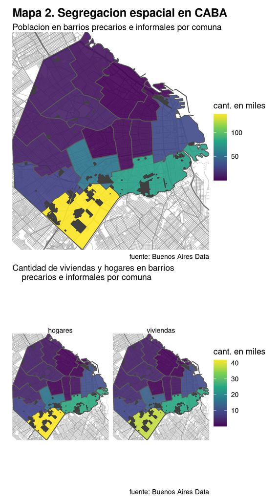

```r
mapa2.1 <- ggmap(mapa_caba)+
  geom_sf(data=poblacion_bp_xcomuna_geo, aes(fill=poblacion/1000),
          inherit.aes = FALSE, alpha=0.9)+
  geom_sf(data=barriosp, color="grey25", fill="grey25", inherit.aes = FALSE)+
  scale_fill_viridis_c() +
  theme_void() +
    theme(plot.title = element_text(face="bold", size=15)) +
    labs(title = "Mapa 2. Segregacion espacial en CABA",
    subtitle = "Poblacion en barrios precarios e informales por comuna",
    caption = "fuente: Buenos Aires Data",
    fill = "cant. en miles")
mapa2.2 <- ggmap(mapa_caba)+
  geom_sf(data=datos_bp_xcomuna_geo, aes(fill=cantidad/1000),
          inherit.aes = FALSE, alpha=0.9)+
  scale_fill_viridis_c() +
  geom_sf(data=barriosp, color="grey25", fill="grey25", inherit.aes = FALSE)+
  theme_void() +
    theme(plot.title = element_text(face="bold", size=15)) +
    labs(subtitle = "Cantidad de viviendas y hogares en barrios
    precarios e informales por comuna",
    caption = "fuente: Buenos Aires Data",
    fill = "cant. en miles")+
    facet_wrap(~indicador)
(mapa2.1/mapa2.2)
```

Los mapa coropléticos permite identificar patrones espaciales con facilidad. Es así que nos muestran mucho más inmediantamente que el gráfico de barras que la concentración de la población que vive en barrios precarios e informales se localiza en la zona sur y este de la ciudad, poniendo de manifiesto la existencia de un patrón evidente de segregación socioespacial.